# Final Paper

STOR 520.001 Group 1

December 06, 2023

# Introduction

> **India’s construction sector levels up as housing demand spurs economy** ([Reuters, 2023](https://www.reuters.com/world/india/indias-construction-sector-levels-up-housing-demand-spurs-economy-2023-12-02/))

> **The housing crisis for the poor in India’s capital: Lack of affordable housing, reduced land entitlements and accelerated housing for the privileged are behind the crisis.** ([Aljazeera, 2023](https://www.aljazeera.com/gallery/2023/8/30/photos-the-housing-crisis-for-the-poor-in-indias-capital))

As alluded to by the first headline, the housing market in India is [booming](https://www.india.gov.in/topics/housing), with [sales rising 36%](https://www.reuters.com/world/india/indias-construction-sector-levels-up-housing-demand-spurs-economy-2023-12-02/) in just the third of quarter of this year across major urban centers. This number is only is expected to continue rising as India’s [large generation of young people begin buying](https://www.ft.com/content/b380f48f-2e9a-4bcb-a372-8eb9b58ca290). Importantly, however, as alluded to by the second headline above, access to quality housing is not a given for large parts of the population. The housing gap in major urban areas has been steadily rising over the past decade, [disproportionately impacting low-income groups](https://www.aljazeera.com/gallery/2023/8/30/photos-the-housing-crisis-for-the-poor-in-indias-capital). This problem, while linked to a number of social and economic factors, is in part due to India becoming the [world’s most populous country](https://www.statista.com/statistics/262879/countries-with-the-largest-population/) just this year.

When housing *is* available for these groups, it is often of low quality, with such housing often being concentrated in neglected urban areas called [“slums.”](https://www.theworldmind.org/home/2019/3/1/mumbais-slums-the-positives-and-negatives) These areas often suffer from additional issues related to lack of vital resources and healthcare. As of 2013, a whopping [65 million people Indians in slums](https://www.thehindu.com/todays-paper/tp-national/tp-newdelhi/65-million-people-live-in-slums-in-india-says-census-data/article5188234.ece). The discrepancy in housing quality between “slums” and more upscale urban areas highlights just one variable aspect of the Indian urban housing market. It also indicates that there exists a complex network of socioeconomic factors that determine housing quality and cause the ebb and flow of the market over time.

In the project at hand, we are interested in building models of the housing market in major Indian urban areas to gain an understanding of what factors influence quality and affordability. Specifically, our goal is to determine first: *what public information about urban properties best predict rent price?* That is, we wish to build a model of rent price that is built on a variety of characteristics that are publicly available. Such a model could be used by an individual looking for housing and inform her about what things to keep in mind when finding housing, whether her goal is quality, affordability, or both. The modeling might also shed light on the problem of India’s housing gap and the discrepancy in affordable housing access between socioeconomic groups.

Second, we wish to determine *if there exist any interesting (including unfair) trends in the characteristics of a property depending on the preferred tenant, such as housing targeted at families*. To do so, our goal is to build classification models predicting preferred tenant status based on publicly available information. Such a model will shed light on the accessibility of quality and affordable housing to families and may illuminate ways in which property listings are biased, whether it be in quality, rent price, location, or other characteristics.

# Data

For the analysis at hand, we are analyzing property listings from **[MagicBricks.com](https://www.magicbricks.com)**, an Indian buying, selling, and renting website with thousands of postings. The data were web-scraped from most or all listings over the summer of 2022 and uploaded to Kaggle.com. While the website advertises properties all over the country, our data is specific to for-rent locations in six major Indian cities: Kolkata, Mumbai, Bangalore, Delhi, Chennai, and Hyderabad. The complied dataset has 4745 property listings, the vast majority of which are smaller apartments located within a larger apartment-style building.

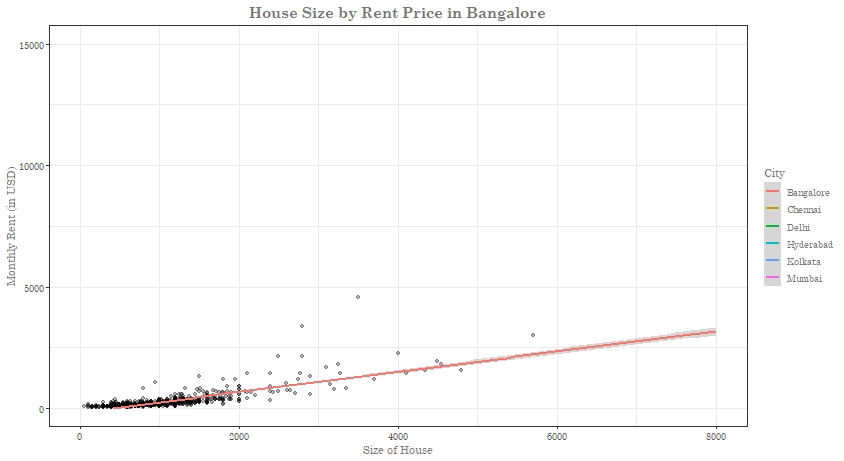

As observed in the figure above, property `Size` is another variable of interest, being measured in square feet. An important transformation of this variable that will be useful in model building is rent price *per square foot*, which is calculated as $\frac{\verb|Rent Price|}{\verb|Size|}$. Related to property size is number of rooms, broken down into `BHK` (bathrooms, halls, and kitchens) and `Bathrooms`, and `Floor Number`, listed according to the template “Floor $X$ of $Y$.” Importantly, we divided this variable into two separate ones: `Apt Floor` (i.e., $X$, or the actual floor number of a property) and `Total Floors` (i.e., $Y$, or the total floors in the building). Doing so allows us to analyze their separate effects in our models, but importantly we want to use one or the other since they are very dependent.

The remaining variables are categorical variables: `City`, taking one of the six values listed above; `Area Locality`, or the specific name of the neighborhood or part of town in which the property is located; `Furnishing Staus`, or whether the property comes fully furnished, semi-furnished, or neither; `Point of Contact`, or who to contact with inquiries about the property (i.e., the owner directly or an agent); `Area Type` or the area of the house for which `Size` was measured (e.g., just the interior of the house – or “carpet area” – versus the interior plus the space the walls take up – or “built area” – versus the “built area” plus any external fixtures such as balconies – or “super built area”; of note is that these differences affect the how the `Size` variable was measured, so including `Area Type` in models will control for these differences); and finally `Tenant Preferred`, indicating who the property is intended to house.

The `Tenant Preferred` variable, as described in the introduction, is of most importance to our classification models. Importantly, it takes three values: “Bachelors”, “Family”, or “Bachelors/Family.” Because classification models rely on *two* outcomes, and because the question of family housing is what we are interested in, we determined that the variable should be reduced to “Family” (taking a value of 1) or “Other/No Preference” (taking a value of 0). This transformation will allow us to analyze whether family-specific listings can be predicted using the rest of the variables.

Finally, each listing comes with a date stamp. Importantly, data were collected from mid-April to mid-July, so not every month has full representation. The number of listings broken down by month and city are presented in the table below. We see that, as expected, April and July have a fewer number of listings than May and June.

| Month | Bangalore | Chennai | Delhi | Hyderabad | Kolkata | Mumbai | Total |
| --- | --- | --- | --- | --- | --- | --- | --- |
| April | 41 | 24 | 55 | 32 | 41 | 35 | 228 |
| July | 136 | 204 | 95 | 223 | 45 | 275 | 978 |
| June | 350 | 333 | 206 | 295 | 265 | 409 | 1858 |
| May | 358 | 330 | 249 | 318 | 173 | 253 | 1681 |
| Total | 885 | 891 | 605 | 868 | 524 | 972 | 4745 |

# Results

## *What public information about urban properties best predict rent price?*

To answer our first questions and predict `Rent`, we used multiple predictive modeling techniques and computed the out-of-sample MAE to make comparisons. First, we made a null model and used Leave-One-Out Cross-Validation to estimate an out-of-sample MAE. This gives us a baseline for making predictions with more complex models.

We then tried some linear models using variables we thought could be strong predictors in the EDA, i.e., ones that (a) graphically showed a relationship with `Rent`, (b) theoretically showed a relationship with `Rent` (e.g., the `Size` variable), and (c) graphically or theoretically showed a relationship with *another* variable in the model (e.g., the dependency of `Apt Floor` and `Total Floors`; see Linear Model 1).

### Linear Model 1

The first model used was
$$\verb|Rent| \sim \verb|Size| + \verb|City| + \verb|Area_Type| +
\verb|Apt_Floor|* \verb|Total_Floors|$$
Note that the `AptFloor` $\times$ `TotalFloors` interaction accounts for the fact that they are strongly dependent.

### Linear Model 2

The second model used was
$$\verb|Rent| \sim \verb|Size| + \verb|Apt_Floor| + \verb|Month| +
\verb|BHK|*\verb|Bathroom|$$

Note that the `BHK` $\times$ `Bathroom` interaction accounts for the fact that they are strongly linked in terms of total number of rooms in the house.

### Model Comparison and Final Model

| Model | Out-of-Sample MAE |
| --- | --- |
| Null Model 360 | 360 |
| Linear1 | 251 |
| Linear2 | 234 |
| Polynomial with log(Rent) | 132 |
| Elastic Net | 179 |
| Elastic Net with log(Rent) | 122 |

| Variable | Coefficient |
| --- | --- |
| (Intercept) | 5.80000 |
| Size | 0.00002 |
| Tenant Preferred | 0.01850 |
| City: Delhi | -0.07170 |
| City: Hyderabad | 0.00288 |
| Area Type: Super Area | -0.02760 |
| Point of Contact: Contact Agent | 0.18500 |
| Point of Contact: Contact Owner | -0.17100 |

# Conclusion